# Biomedical signal processing and visualisation using R

VII Encontro Nacional de Engenharia Biomecânica

Prof. Adriano de Oliveira Andrade, PhD - adriano@ufu.br

01 June, 2022

# 1 Biomedical signal visualisation

## 1.1 Static visualising with R

The first thing to do is open the data file. The data set in this example is derived from inertial data, such as accelerometer, magnetometer, and gyroscope. The information was saved in an `.xlsx` (Excel) file.

```r
library(openxlsx)

df <- openxlsx::read.xlsx("V16C1RCC92.xlsx") # load inertial data from Excel file

names(df) # display the variable names
```

```
##  [1] "[Time]"    "[G1.X]"    "[G1.Y]"    "[G1.Z]"    "[G2.X]"    "[G2.Y]"
##  [7] "[G2.Z]"    "[G3.X]"    "[G3.Y]"    "[G3.Z]"    "[G4.X]"    "[G4.Y]"
## [13] "[G4.Z]"    "[A1.X]"    "[A1.Y]"    "[A1.Z]"    "[A2.X]"    "[A2.Y]"
## [19] "[A2.Z]"    "[A3.X]"    "[A3.Y]"    "[A3.Z]"    "[A4.X]"    "[A4.Y]"
## [25] "[A4.Z]"    "[M1.X]"    "[M1.Y]"    "[M1.Z]"    "[M2.X]"    "[M2.Y]"
## [31] "[M2.Z]"    "[M3.X]"    "[M3.Y]"    "[M3.Z]"    "[M4.X]"    "[M4.Y]"
## [37] "[M4.Z]"    "[EMG1]"    "[EMG2]"    "[PULSE.A]" "[PULSE.B]"
```

The names of the variables can be improved to make graphic generation easier.

```r
library(stringr)

aa <- names(df) # assigning the variable names to a variable

# identifying and replacing patterns in the names of the variables
aa <- str_replace(string = aa, pattern = c("\\["), replacement = "")
aa <- str_replace(string = aa, pattern = "\\]", replacement = "")
aa <- str_replace(string = aa, pattern = "\\.", replacement = "")

names(df) <- aa # assigning the altered names to the variables

names(df)
```

```
##  [1] "Time"   "G1X"    "G1Y"    "G1Z"    "G2X"    "G2Y"    "G2Z"    "G3X"
##  [9] "G3Y"    "G3Z"    "G4X"    "G4Y"    "G4Z"    "A1X"    "A1Y"    "A1Z"
## [17] "A2X"    "A2Y"    "A2Z"    "A3X"    "A3Y"    "A3Z"    "A4X"    "A4Y"
## [25] "A4Z"    "M1X"    "M1Y"    "M1Z"    "M2X"    "M2Y"    "M2Z"    "M3X"
## [33] "M3Y"    "M3Z"    "M4X"    "M4Y"    "M4Z"    "EMG1"   "EMG2"   "PULSEA"
## [41] "PULSEB"
```

As the data is now available in the global environment it is possible to visualize it by using static and interactive graphics. Let’s start looking on how to plot the signal in a static way, which is very suitable for publications in journals, theses and other static materials.

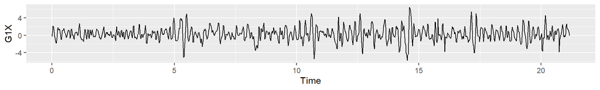

```r
library(ggplot2)

gg <- ggplot() # create the graphic object
gg <- gg + ggplot2::geom_line(data = df,
                              mapping = aes(x = Time, y = G1X)) # adding layers to the graphic object
gg # display the graphic on the screen
```

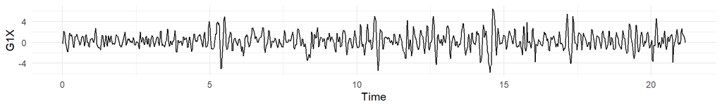

```r
gg <- gg + theme_minimal() #changing the appearance of the theme
gg # display the graphic on the screen
```

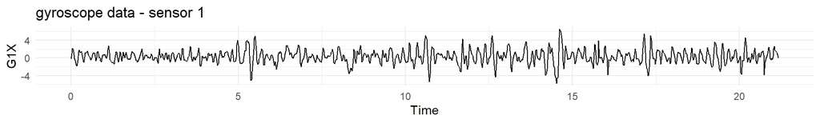

```r
gg <- gg + ggplot2::ggtitle(label = "gyroscope data - sensor 1")

gg # display the graphic on the screen
```

If you wish to plot several biomedical time series in the same graphic or in distinct subpanels the data should be first reorganized to easy plotting the data.

```r
library(tidyr)

df.long <- pivot_longer(data = df, cols = (2:length(df)),
                        names_to = "variable",
                        values_to = "value")
head(df.long, n = 10L)
```

```
## # A tibble: 10 x 3
##     Time variable    value
##    <dbl> <chr>       <dbl>
##  1     0 G1X      -0.298
##  2     0 G1Y      -1.66
##  3     0 G1Z       0.0687
##  4     0 G2X       0.633
##  5     0 G2Y       0.679
##  6     0 G2Z       2.77
##  7     0 G3X       0.00763
##  8     0 G3Y       0.00763
##  9     0 G3Z       0.00763
## 10     0 G4X       0.00763
```

```r
# converting the variable names from string to factors
# to sort out the variables according to their levels
df.long$variable <- factor(df.long$variable,
                           levels = df.long$variable %>% unique())
```

Once the data is organized it can be plotted by using the `ggplot2` package.

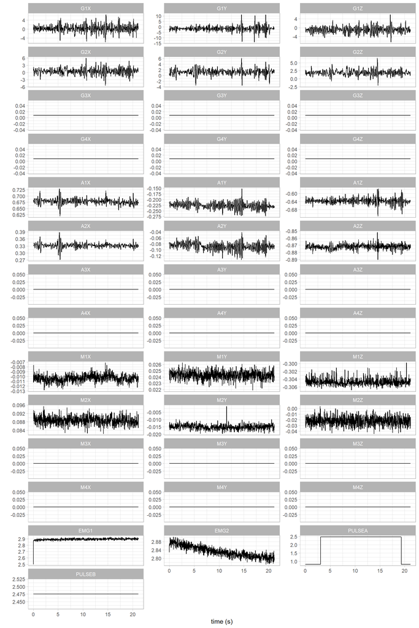

```r
g <- ggplot(data = df.long,
            mapping = aes(x = Time, y = value)) +
  geom_line() +
  facet_wrap( ~ variable, ncol = 3, scales = "free_y") +
  theme_light() + labs(y = "", x = "time (s)")

g
```

If you want to plot several waveforms on the same graph, you can choose the signals you want and plot them as shown below.

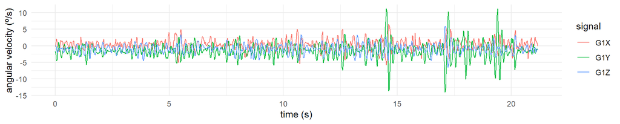

```r
library(dplyr)
library(ggplot2)

df.filtered <- df.long %>% filter(variable == "G1X" |
                                    variable == "G1Y" |
                                    variable == "G1Z")

g <- ggplot(data = df.filtered,
            mapping = aes(x = Time,
                          y = value,
                          color = interaction(variable))) +
  geom_line() + theme_minimal() + labs(color = "signal",
                                       x = "time (s)",
                                       y = "angular velocity (º/s)")
g
```

Several waveforms can be grouped and plotted in panels based on specific criteria.

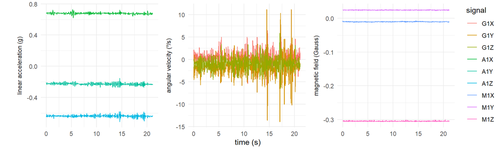

```r
df.filtered <- df.long %>% filter(variable == "G1X" |
                                    variable == "G1Y" |
                                    variable == "G1Z" |
                                    variable == "A1X" |
                                    variable == "A1Y" |
                                    variable == "A1Z" |
                                    variable == "M1X" |
                                    variable == "M1Y" |
                                    variable == "M1Z")

df.filtered$sensor <- str_sub(df.filtered$variable, 1, 1)

g <- ggplot(data = df.filtered,
            mapping = aes(x = Time,
                          y = value,
                          color = interaction(variable))) +
  geom_line() +
  facet_wrap( ~ sensor, ncol = 3, scales = "free_y",
              strip.position = "left",
              labeller = as_labeller(c(A = "linear acceleration (g)",
                                       G = "angular velocity (º/s)",
                                       M = "magnetic field (Gauss)"))) +

  theme_minimal() + labs(color = "signal",
                         x = "time (s)",
                         y = "") +
  theme(strip.background = element_blank(),
        strip.placement = "outside")
g
```

Static figures can be saved in vectorial and several other formats.

```r
ggsave(filename = "figure1.pdf", plot = g, width = 160,
       height = 75, units = "mm")

ggsave(filename = "figure1.png", plot = g, width = 160,
       height = 75, units = "mm")

ggsave(filename = "figure1.tiff", plot = g, width = 160,
       height = 75, units = "mm")
```

**Now, it is time for action!**

> Generate a static graph with ‘ggplot2’, containing a panel for the X axis of each sensor type, i.e., accelerometer, gyroscope, and magnetometer. In each panel, two time-series should be plotted for each IMU. i.e. IMU1 and IMU2, and the time-series of IMU1 should be plotted in black while those for IMU2 in red. Don’t forget to include the axes’ names and units of measurement!

## 1.2 Interactive visualisation of biomedical signals with R

When inspecting and processing biomedical signals, interactive data visualisation is critical for understanding information, understing distinct parts of the signal, paying attention to details, and identifying trends, discontinuities, or outliers, because this type of data visualisation allows us to zoom in on periods of interest, highlight points, and mark events that aid in data analysis. We bring our graphics to life with R’s `dygraphs` package. It’s easy to make a dynamic graphic with this package, and the code below demonstrates how!

```r
library(dygraphs)

df.filtered <- df %>%
  dplyr::select(Time, G1Y) # selecting the Time and G1Y columns

dygraph(df.filtered, width = "100%", height = "200px" ) # generating the dynamic graph
```

[interactive chart not shown]

Even though we can zoom in on signal segments by clicking and dragging and re-view the entire signal with a double click, visualisation along the signal is not possible. We can use the `dyRangeSelector()` function when we are interested in visualising along the signal or observing time intervals.

```r
dygraph(df.filtered, width = "100%", height = "200px") %>% # generating the dynamic graph
  dyRangeSelector(dateWindow = c(10,17)) # adding a range selector (rectangular window of 7 s)
```

[interactive chart not shown]

In addition, the `dyEvent()` function is used to specify the times when events occurred. Event marking is particularly interesting when we believe that the event has probably influenced a noticeable change in the time series and should be observed. In other hand, the `dyShading()` function allows us to highlight a period or several periods in the time series data. Additionally, you can specify the color of the series lines and other graphical styling by using the `dyOptions()` function.

```r
df.filtered <- df %>%
  dplyr::select(Time, G1X, G1Y, G1Z) # selecting the Time and gyroscope signals of IMU1

dygraph(df.filtered, width = "100%", height = "200px", xlab = "time (s)", ylab = "angular velocity (º/s)") %>% # generating the dynamic graph
  dyRangeSelector(dateWindow = c(15,20)) %>% # adding a range selector
  dyOptions(colors = c("#ae0001","#d3a625","#2a623d")) %>% # adding color palette
  dyShading(from = "17.02", to = "17.34", color = "#cee6fd") %>% # adding shadow
  dyShading(from = "19.18", to = "19.54", color = "#fff5da") %>% # adding shadow
  dyEvent(c("17.02", "17.34"), c("start", "end"), labelLoc = "top") # adding event
```

[interactive chart not shown]

# 2 Pre-processing biomedical signals

## 2.1 Signal windowing

Signal windowing is the method of dividing a signal into sections to facilitate analysis and improve the sampled signal’s spectral properties. Different types of windows can typically be used for windowing (i.e., rectangular window, Hanning window, Hamming window, and Kaiser-Bessel window, among other types of window).

In practice, defining a window size given in units of time or number of samples is extremely difficult. We cannot segment the signal consistently if we select a size that is too small or too large. Determining the window size requires knowledge of the investigated phenomenon, sampling frequency, and signal duration.

Signal windowing can also be performed with or without overlap. When there is overlap, a window intersects with the window next to it at some point in time. When there is no overlap, on the other hand, the start time of one window does not overlap with the start time of the adjacent window. When investigating signal behaviour over time using features, non-overlapping rectangular windows are typically employed. This window type is simple and straightforward to implement in R.

We will window the EMG signal of channel 2 with 500-ms rectangular windows that do not overlap. Knowing the signal’s sampling frequency and duration enables us to determine the beginning and ending indices of each window.

For the sampling frequency ($f_s$), it is enough to consider the inverse of temporal resolution ($\Delta t$), that is,

$$f_s = \frac{1}{\Delta t}$$

the inverse of the time difference between two consecutive samples.

```r
dt <- df$Time[2]-df$Time[1] # temporal resolution (s)

paste("Temporal resolution is", dt, "s")
```

```
## [1] "Temporal resolution is 0.02 s"
```

```r
fs <- 1/(dt) # sampling frequency (Hz)

paste("Sampling frequency is", fs, "Hz")
```

```
## [1] "Sampling frequency is 50 Hz"
```

With the sampling frequency and window size defined in time, we were able to calculate the number of samples for each window.

```r
n.wnd <- (500/1000)*fs # number of samples for each window

paste(n.wnd, "samples by window")
```

```
## [1] "25 samples by window"
```

Now, we have to keep in mind that windowing cannot exceed the duration of the signal. In addition, the end index of the first window will be the start index of the second window and thus successively until the last window.

```r
indx1 <- seq(from = 1,
             to = floor(length(df$Time) - n.wnd),
             by = n.wnd)

print(paste("Start indices:",
            paste(indx1,collapse = ", "),
            collapse = "\n"))
```

```
## [1] "Start indices: 1, 26, 51, 76, 101, 126, 151, 176, 201, 226, 251, 276, 301, 326, 351, 376, 401, 426, 451, 476, 501, 526, 551, 576, 601, 626, 651, 676, 701, 726, 751, 776, 801, 826, 851, 876, 901, 926, 951, 976, 1001, 1026"
```

```r
indx2 <- seq(from = 1 + n.wnd,
             to = length(df$Time),
             by = n.wnd)

print(paste("End indices:",
            paste(indx2,collapse = ", "),
            collapse = "\n"))
```

```
## [1] "End indices: 26, 51, 76, 101, 126, 151, 176, 201, 226, 251, 276, 301, 326, 351, 376, 401, 426, 451, 476, 501, 526, 551, 576, 601, 626, 651, 676, 701, 726, 751, 776, 801, 826, 851, 876, 901, 926, 951, 976, 1001, 1026, 1051"
```

With dygraphs, we can graphically illustrate the windowing performed. To indicate the beginning and end of windows, we can use the `dyEvent()` function.

```r
df.filtered <- df %>%
  dplyr::select(Time, EMG2)


dygraph(df.filtered,  width = "100%", height = "200px", main = "EMG - channel 2", ylab = "", xlab = "time (s)") %>%
  dyRangeSelector(dateWindow = c(1.95,3.55)) %>%
  dyOptions(colors = "#fb8500") %>%
  dyShading(from = df$Time[indx1[5]], to = df$Time[indx2[5]], color = "#fee44047") %>%
  dyEvent(c(df$Time[indx1[5]],df$Time[indx2[5]]), c("wnd 5 - start", "wnd 5 - end"), labelLoc = "bottom") %>%
  dyShading(from = df$Time[indx1[6]], to = df$Time[indx2[6]], color = "#fdf4db") %>%
  dyEvent(c(df$Time[indx1[6]],df$Time[indx2[6]]), c("wnd 6 - start", "wnd 6 - end"), labelLoc = "top") %>%
  dyShading(from = df$Time[indx1[7]], to = df$Time[indx2[7]], color = "#fee44047") %>%
  dyEvent(c(df$Time[indx1[7]],df$Time[indx2[7]]), c("wnd 7 - start", "wnd 7 - end"), labelLoc = "bottom")
```

[interactive chart not shown]

## 2.2 Removing linear and non-linear trends from biomedical signals

Trends are always present in biomedical signals. Let’s study the script below and see how we can visualise and remove them.

```r
dygraph(df.filtered, width = "100%", height = "200px", main = "EMG - channel 2") %>% dyAxis("x", label = "time (s)") %>%
  dyRangeSelector() %>%
  dyOptions(colors = "#fb8500")
```

[interactive chart not shown]

```r
trend <- vector(mode = "numeric", length = length(indx1))
tm <- vector(mode = "numeric", length = length(indx1))

for(i in 1:length(trend)){

  trend[i] <- median(df$EMG2[indx1[i]:indx2[i]])
  tm[i] <- mean(df$Time[indx1[i]:indx2[i]])

}

dygraph(data.frame(wnd = 1:length(trend),
                   trend),
        width = "100%", height = "200px",
        main = "trend",
        xlab = "window",
        ylab = "amplitude"
) %>%
  dyRangeSelector() %>%
  dyOptions(colors = "#bf0000")
```

[interactive chart not shown]

```r
trd <- spline(x = tm,
              y = trend,
              xout = df$Time,
              method = "fmm")$y

df.filtered$trend <- trd


dygraph(df.filtered, width = "100%", height = "200px", main = "EMG and trend", ylab = "", xlab = "time (s)") %>%
  dyRangeSelector() %>%
  dyOptions(colors = c("#fb8500","#bf0000"))
```

[interactive chart not shown]

```r
EMG2r <- data.frame(Time = df.filtered$Time,
                    EMGr = df.filtered$EMG2 - df.filtered$trend)

dygraph(EMG2r, width = "100%", height = "200px", main = "EMG without trends", ylab = "", xlab = "time (s)") %>%
  dyRangeSelector() %>%
  dyOptions(colors = "#e0301e")
```

[interactive chart not shown]

## 2.3 Filtering

Filtering is a relevant signal processing step. Let’s study the script below to understand how basic filtering can be performed in R.

```r
library(signal)
library(dygraphs)

df.filtered <- df %>%
  dplyr::select(Time, A2Y)

dygraph(df.filtered,width = "100%", height = "200px",
        xlab = "time (s)",
        ylab = "linear acceleration (g)") %>%
  dyRangeSelector() %>%
  dyOptions(colors = "#800080")
```

[interactive chart not shown]

```r
dt <- df$Time[2]-df$Time[1] # temporal resolution (s)

paste("Temporal resolution is", dt, "s")
```

```
## [1] "Temporal resolution is 0.02 s"
```

```r
fs <- 1/(dt) # sampling frequency (Hz)

paste("Sampling frequency is", fs, "Hz")
```

```
## [1] "Sampling frequency is 50 Hz"
```

```r
fc_l <- 1 # cutoff frequency (Hz)

fc_h <- 7 # cutoff frequency (Hz)

paste("Cutoff frequency [",fc_l,"-",fc_h, "] Hz", sep = "")
```

```
## [1] "Cutoff frequency [1-7] Hz"
```

```r
n <- 2 # order

paste("Filter order is", n)
```

```
## [1] "Filter order is 2"
```

```r
w <- c(fc_l,fc_h)/(fs/2) # digital frequency

paste("Digital frequency is [",
      paste(w, collapse = "-"), "]", sep = "")
```

```
## [1] "Digital frequency is [0.04-0.28]"
```

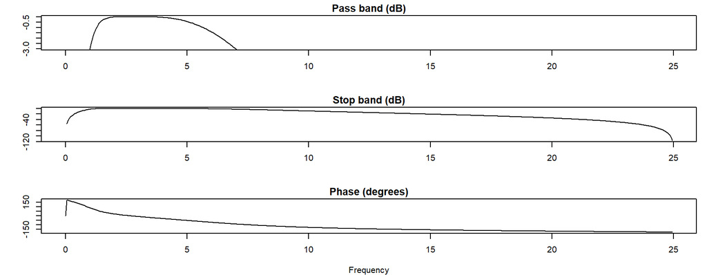

```r
bt <- signal::butter(n = n, W = w, type = "pass") # Butterworth filter coefficients

freqz(filt = bt, Fs = fs)
```

```r
df.filtered$A2Yf <- filtfilt(bt,df.filtered$A2Y)

dygraph(df.filtered, width = "100%", height = "200px",
        xlab = "time (s)",
        ylab = "linear acceleration (g)") %>%
  dyRangeSelector() %>%
  dyOptions(colors = c("#800080", "black"))
```

[interactive chart not shown]

```r
library(psd)

psd.A2Y <- pspectrum(df.filtered$A2Y,
                     verbose = FALSE,
                     niter=10, AR=TRUE,
                     x.frqsamp=fs,
                     plot=FALSE) # adaptive multitaper spectrum estimation

psd.A2Y <- psd.A2Y[c("freq","spec")] %>%
  as.data.frame()

psd.A2Yf <- pspectrum(df.filtered$A2Yf, verbose = FALSE,
                      niter=10, AR=TRUE,
                      x.frqsamp=fs,
                      plot=FALSE) # adaptive multitaper spectrum estimation

psd.A2Yf <- psd.A2Yf[c("freq","spec")] %>%
  as.data.frame()
```

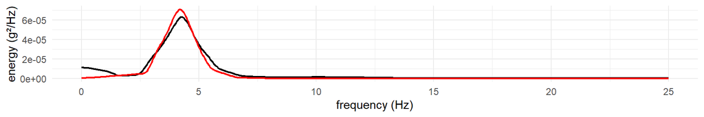

```r
g <- ggplot()
g <- g + geom_line(data = psd.A2Y,
                   mapping = aes(x = freq,
                                 y = spec),
                   color = "black",
                   size = 0.75)
g <- g + geom_line(data = psd.A2Yf,
                   mapping = aes(x = freq,
                                 y = spec),
                   color = "red",
                   size = 0.75)
g <- g + theme_minimal()
g <- g + labs(x = "frequency (Hz)",
              y = "energy (g²/Hz)")
g
```

**Now, it is time for action!**

> Choose the signal that has the most evident linear trend. Apply a Butterworth filter to remove this trend.

# 3 Visualisation of features extracted from biomedical signals

Bo Hjorth introduced Hjorth parameters, which are indicators of statistical properties used in signal processing in the time domain, in 1970. Activity, Mobility, and Complexity are the three parameters, which are defined below. Let’s implement these formulas in R and estimate these parameters as features varying over the time, and then compare the results of these features estimated for both non-filtered (raw) and filtered signals.

$$activity = \sigma^2 = \frac{1}{N-1} \sum_{i=1}^{N}(x_i - \mu)^2$$

$$mobility = \frac{\sigma_d}{\sigma}$$

$$complexity = \frac{\sigma_{dd}/\sigma_d}{\sigma_d/\sigma}$$

```r
dt <- df$Time[2]-df$Time[1] # temporal resolution (s)

paste("Temporal resolution is", dt, "s")
```

```
## [1] "Temporal resolution is 0.02 s"
```

```r
fs <- 1/(dt) # sampling frequency (Hz)

paste("Sampling frequency is", fs, "Hz")
```

```
## [1] "Sampling frequency is 50 Hz"
```

```r
n.wnd <- (1)*fs # number of samples for each window

paste(n.wnd, "samples by window")
```

```
## [1] "50 samples by window"
```

```r
indx1 <- seq(from = 1,
             to = floor(length(df$Time) - n.wnd),
             by = n.wnd)

print(paste("Start indices:",
            paste(indx1,collapse = ", "),
            collapse = "\n"))
```

```
## [1] "Start indices: 1, 51, 101, 151, 201, 251, 301, 351, 401, 451, 501, 551, 601, 651, 701, 751, 801, 851, 901, 951, 1001"
```

```r
indx2 <- seq(from = 1 + n.wnd,
             to = length(df$Time),
             by = n.wnd)

print(paste("End indices:",
            paste(indx2,collapse = ", "),
            collapse = "\n"))
```

```
## [1] "End indices: 51, 101, 151, 201, 251, 301, 351, 401, 451, 501, 551, 601, 651, 701, 751, 801, 851, 901, 951, 1001, 1051"
```

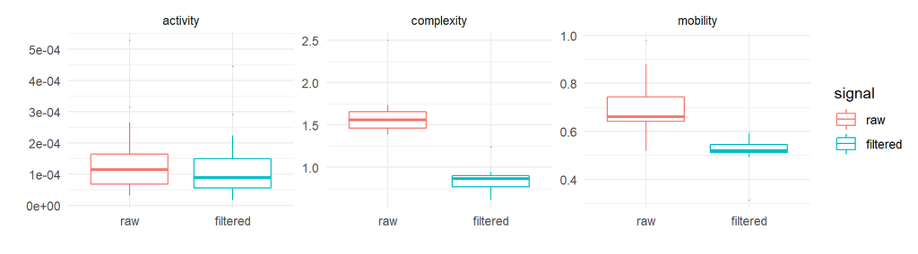

```r
v.var <- vector(mode = "numeric", length = length(indx1))
v.mob <- vector(mode = "numeric", length = length(indx1))
v.comp <- vector(mode = "numeric", length = length(indx1))

v.var.f <- vector(mode = "numeric", length = length(indx1))
v.mob.f <- vector(mode = "numeric", length = length(indx1))
v.comp.f <- vector(mode = "numeric", length = length(indx1))


for(i in 1:length(indx1)){

  v.var[i] <- var(df.filtered$A2Y[indx1[i]:indx2[i]])

  v.mob[i] <- sqrt((var(diff(df.filtered$A2Y[indx1[i]:indx2[i]])))/var(df.filtered$A2Y[indx1[i]:indx2[i]]))

  v.comp[i] <- sqrt(var(diff(diff(df.filtered$A2Y[indx1[i]:indx2[i]])))/ var(diff(df.filtered$A2Y[indx1[i]:indx2[i]])))/v.mob[i]


  v.var.f[i] <- var(df.filtered$A2Yf[indx1[i]:indx2[i]])

  v.mob.f[i] <- sqrt((var(diff(df.filtered$A2Yf[indx1[i]:indx2[i]])))/var(df.filtered$A2Yf[indx1[i]:indx2[i]]))

  v.comp.f[i] <- sqrt(var(diff(diff(df.filtered$A2Yf[indx1[i]:indx2[i]])))/ var(diff(df.filtered$A2Yf[indx1[i]:indx2[i]])))/v.mob[i]


}


features <- data.frame(
  activity = v.var,
  mobility = v.mob,
  complexity = v.comp,
  activity.f = v.var.f,
  mobility.f = v.mob.f,
  complexity.f = v.comp.f
)

library(tidyverse)

df.longer <- pivot_longer(data = features,
                          cols = 1:6,
                          names_to = "feature",
                          values_to = "value")

df.longer$signal <- ifelse(is.na(str_extract(df.longer$feature, ".f")),
  "raw", "filtered")

df.longer$signal <- factor(df.longer$signal, levels = c("raw","filtered"))

df.longer$feature <- str_replace(df.longer$feature,
                                 fixed(".f"),
                                 "")
ggplot(data = df.longer,
       mapping = aes(x = signal, y = value, color = signal)) +
  geom_boxplot(outlier.size = 0.2,
               outlier.shape = 1) +
  facet_wrap(~feature, ncol = 3, scales = "free_y") +
  theme_minimal() +
  labs(x = "", y = "")
```

**Now, it is time for action!**

> Estimate the root mean square (RMS) of the filtered and non-filtered signals. The RMS should be estimated for windows of 1 second each, without overlapping. Contrast the estimated features through box plots.